# Homework 1

Author

Affiliation

Ahsan

Old Dominion University

Understanding labor market outcomes is crucial for gaining insights into economic dynamics and societal structures. The 1976 Panel Study of Income Dynamics (PSID) serves as a valuable dataset for such an analysis, capturing a comprehensive snapshot of American households at a particular time. These data document labor market outcomes for women with additional information about their partners’ labor market outcomes. Investigating the factors influencing female wages provides a nuanced perspective on gender dynamics, labor market trends, and the distribution of economic opportunities within households.

Analyzing wages between spouses allows us to explore questions related to gender equity, workforce participation, and the impact of educational attainment. Educational levels, for instance, may influence both the individual’s and the spouse’s earning potential, shedding light on the interplay between education and labor market outcomes within a family unit. Additionally, considering the presence of children in the household introduces a complex dynamic, as it may affect labor force participation, career choices, and subsequently, wages.

Regression analysis emerges as a powerful tool for examining these relationships, enabling the quantification of the impact of various factors on wages. By controlling for relevant characteristics, such as education and the labor market status of partners, regression models can provide a clearer understanding of the specific influences shaping labor market outcomes for women. This exploration not only contributes to our comprehension of societal structures but also provides empirical insights essential for crafting informed policies aimed at fostering equality and economic well-being.

In this homework, you will explore [PSID data](https://vincentarelbundock.github.io/Rdatasets/csv/AER/PSID1976.csv) ([documentation](https://vincentarelbundock.github.io/Rdatasets/doc/AER/PSID1976.html)) and generate empirical insights about the labor market for women in 1976.

## Question 1

Use the data linked above to answer the following.

1. Read the data into an object called `psid`. (**0 Points**)

```r
psid <- read.csv("PSID1976.csv")
dim(psid)
head(psid)
```

```
[1] 753  22
  rownames participation hours youngkids oldkids age education   wage repwage
1        1           yes  1610         1       0  32        12 3.3540    2.65
2        2           yes  1656         0       2  30        12 1.3889    2.65
3        3           yes  1980         1       3  35        12 4.5455    4.04
4        4           yes   456         0       3  34        12 1.0965    3.25
5        5           yes  1568         1       2  31        14 4.5918    3.60
6        6           yes  2032         0       0  54        12 4.7421    4.70
  hhours hage heducation   hwage fincome    tax meducation feducation unemp
1   2708   34         12  4.0288   16310 0.7215         12          7   5.0
2   2310   30          9  8.4416   21800 0.6615          7          7  11.0
3   3072   40         12  3.5807   21040 0.6915         12          7   5.0
4   1920   53         10  3.5417    7300 0.7815          7          7   5.0
5   2000   32         12 10.0000   27300 0.6215         12         14   9.5
6   1040   57         11  6.7106   19495 0.6915         14          7   7.5
  city experience college hcollege
1   no         14      no       no
2  yes          5      no       no
3   no         15      no       no
4   no          6      no       no
5  yes          7     yes       no
6  yes         33      no       no
```

2. Subset the `data.frame` to include only the following columns: (**0 Points**)
- `wage`: wife’s hourly wage in 1975 dollars.
- `hours`: wife’s hours worked in 1975.
- `education`: wife’s education measured in number of years.
- `age`: wife’s age.
- `youngkids`: number of children under six years old.
- `oldkids`: number of children between six and eighteen.
- `hwage`: husband’s hourly wage in 1975 dollars.
- `hhours`: husband’s hours worked in 1975.
- `heducation`: husband’s education measured in number of years.
- `hage`: husband’s age.
- `unemp`: unemployment rate in county of residence, in percentage points.
- `city`: whether the couple lives in a large city.

```r
psid_subset <- c("wage", "hours", "education", "age", "youngkids", "oldkids",
          "hwage", "hhours", "heducation", "hage", "unemp", "city")

psid <- psid[, psid_subset]

psid$wage[is.na(psid$wage)] <- 0

str(psid)
```

```
'data.frame':   753 obs. of  12 variables:
 $ wage      : num  3.35 1.39 4.55 1.1 4.59 ...
 $ hours     : int  1610 1656 1980 456 1568 2032 1440 1020 1458 1600 ...
 $ education : int  12 12 12 12 14 12 16 12 12 12 ...
 $ age       : int  32 30 35 34 31 54 37 54 48 39 ...
 $ youngkids : int  1 0 1 0 1 0 0 0 0 0 ...
 $ oldkids   : int  0 2 3 3 2 0 2 0 2 2 ...
 $ hwage     : num  4.03 8.44 3.58 3.54 10 ...
 $ hhours    : int  2708 2310 3072 1920 2000 1040 2670 4120 1995 2100 ...
 $ heducation: int  12 9 12 10 12 11 12 8 4 12 ...
 $ hage      : int  34 30 40 53 32 57 37 53 52 43 ...
 $ unemp     : num  5 11 5 5 9.5 7.5 5 5 3 5 ...
 $ city      : chr  "no" "yes" "no" "no" ...
```

3. Convert `city` into a binary variable equal to one if the couple lived in a large city and zero otherwise. (**0 Points**)

```r
psid$city <- as.integer(tolower(as.character(psid$city)) %in% c("yes", "1", "true"))

table(psid$city)
```

```
  0   1
269 484
```

4. Create an `employed` variable equal to 1 if the woman worked in 1975. (**0 Points**)

```r
psid$employed <- as.integer(psid$hours > 0)

summary(psid$employed)
```

```
   Min. 1st Qu.  Median    Mean 3rd Qu.    Max.
 0.0000  0.0000  1.0000  0.5684  1.0000  1.0000
```

5. Using functions from the `modelsummary` package, create a summary statistics table. Then, using this table, discuss some empirical facts.[^1] (**2 Points**)

```r
library(modelsummary)
datasummary(
  All(psid) ~ Mean + SD + Min + Median + Max + N,
  data = psid,
  fmt = 2,
  title = "Table 1: Summary statistics, PSID 1976"
)
```

Table 1: Summary statistics, PSID 1976

|  | Mean | SD | Min | Median | Max | N |
| --- | --- | --- | --- | --- | --- | --- |
| wage | 2.37 | 3.24 | 0.00 | 1.62 | 25.00 | 753 |
| hours | 740.58 | 871.31 | 0.00 | 288.00 | 4950.00 | 753 |
| education | 12.29 | 2.28 | 5.00 | 12.00 | 17.00 | 753 |
| age | 42.54 | 8.07 | 30.00 | 43.00 | 60.00 | 753 |
| youngkids | 0.24 | 0.52 | 0.00 | 0.00 | 3.00 | 753 |
| oldkids | 1.35 | 1.32 | 0.00 | 1.00 | 8.00 | 753 |
| hwage | 7.48 | 4.23 | 0.41 | 6.98 | 40.51 | 753 |
| hhours | 2267.27 | 595.57 | 175.00 | 2164.00 | 5010.00 | 753 |
| heducation | 12.49 | 3.02 | 3.00 | 12.00 | 17.00 | 753 |
| hage | 45.12 | 8.06 | 30.00 | 46.00 | 60.00 | 753 |
| unemp | 8.62 | 3.11 | 3.00 | 7.50 | 14.00 | 753 |
| city | 0.64 | 0.48 | 0.00 | 1.00 | 1.00 | 753 |
| employed | 0.57 | 0.50 | 0.00 | 1.00 | 1.00 | 753 |

### Discussion

*** The average women’s education is more than 12 years. In this dataset, they collected data on women aged 30 to 60, and the average age of those women is 42.54. They have more older kids than younger kids.

*** According to the dataset, husbands work around 3 times more than wives, and their wages are also about 3 times higher than women’s wages on average. Husbands’ and wives’ education levels are almost the same, and their average age gap is not big; it is around 3 years.

*** Most women live in urban areas, and only 57% of women are employed.

## Question 2

In this question, you will explore some of the variables in the data.

1. Use the `density()` function to plot the wage distribution for husbands of employed and unemployed women in 1975. What do you learn from this figure? (**2 Points**)

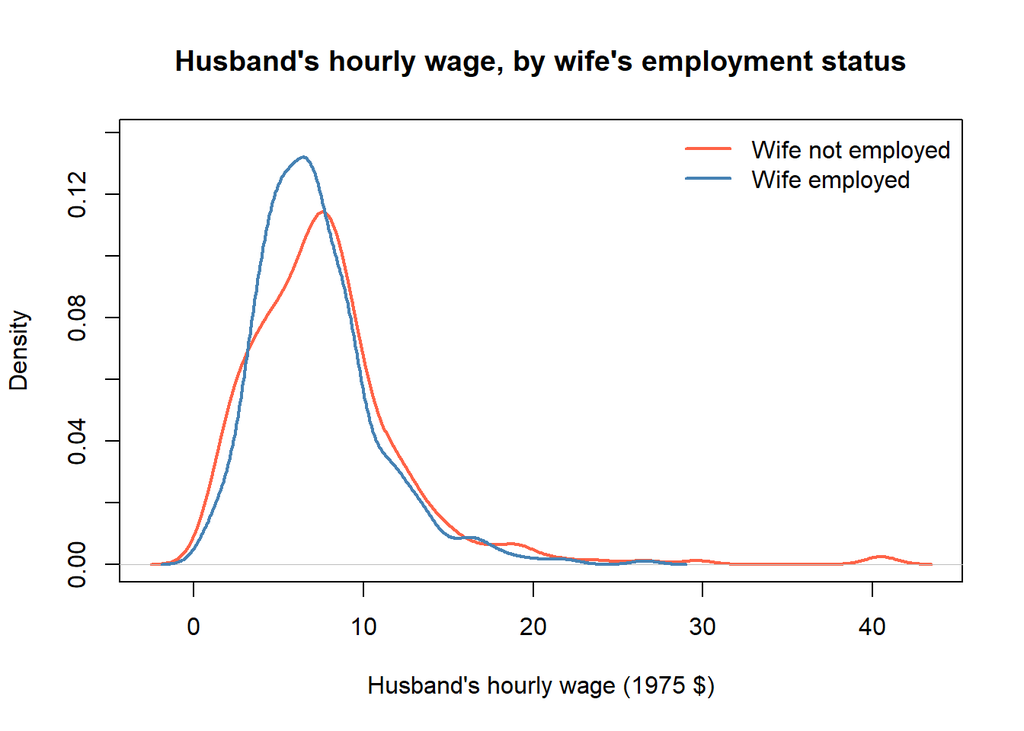

```r
d0 <- density(psid$hwage[psid$employed == 0])
d1 <- density(psid$hwage[psid$employed == 1])

plot(d0,
     main = "Husband's hourly wage, by wife's employment status",
     xlab = "Husband's hourly wage (1975 $)",
     ylab = "Density",
     lwd  = 2,
     col  = "tomato",
     xlim = range(c(d0$x, d1$x)),
     ylim = c(0, max(c(d0$y, d1$y)) * 1.05))
lines(d1, lwd = 2, col = "steelblue")
legend("topright",
       legend = c("Wife not employed", "Wife employed"),
       col    = c("tomato", "steelblue"),
       lwd    = 2, bty = "n")
```

### Discussion

2. Tabulate the *total* number of children for the women sampled. What do you learn from this figure? (**1 Point**)

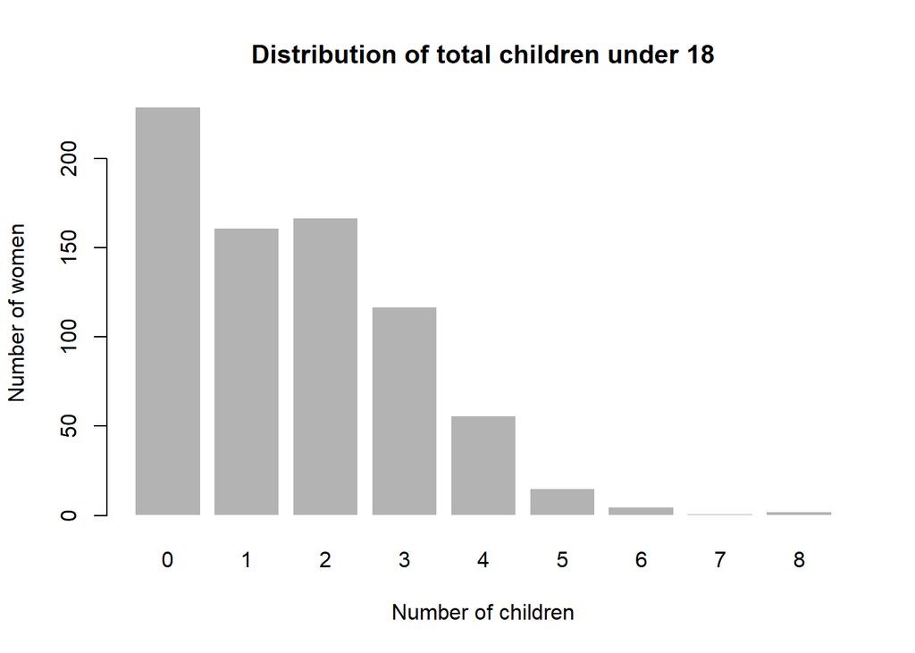

```r
psid$totkids <- psid$youngkids + psid$oldkids
kids_tab <- table(psid$totkids)
barplot(kids_tab,
        main = "Distribution of total children under 18",
        xlab = "Number of children",
        ylab = "Number of women",
        col  = "grey70",
        border = "white")
```

### Discussion

3. Calculate the average number of young and old children (separately) by age. Plot the relationship between children and age. What do you learn from this figure? (**2 Points**)

```
   age youngkids  oldkids
1   30 0.8421053 1.000000
2   31 0.8181818 1.363636
3   32 0.4411765 1.558824
4   33 0.7200000 1.760000
5   34 0.4062500 1.906250
6   35 0.4583333 2.375000
7   36 0.4210526 2.184211
8   37 0.2222222 2.370370
9   38 0.2307692 2.000000
10  39 0.2857143 2.523810
```

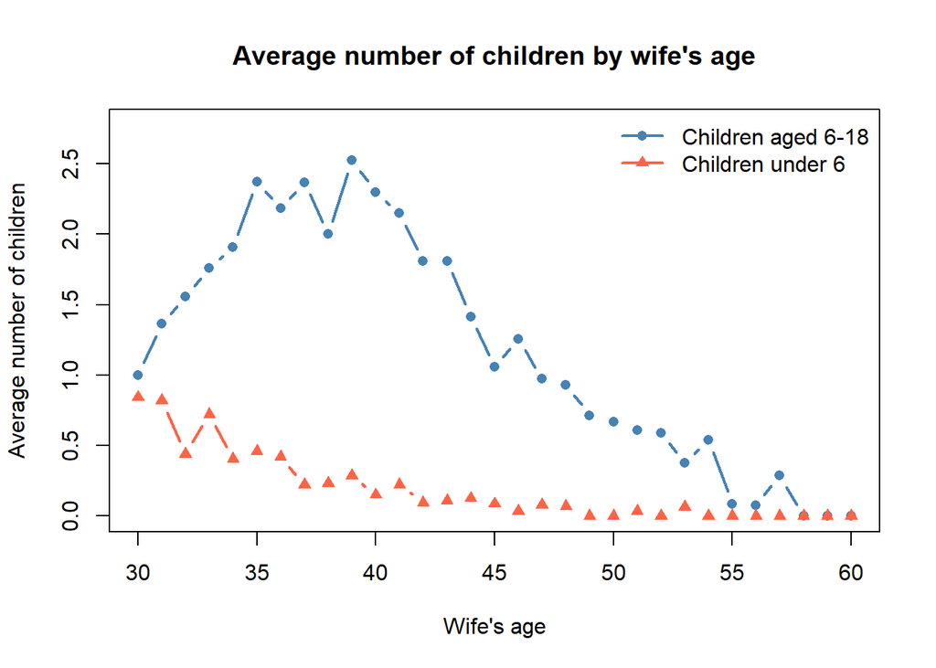

```r
kids_by_age <- aggregate(cbind(youngkids, oldkids) ~ age, data = psid, FUN = mean)
head(kids_by_age, 10)

plot(kids_by_age$age, kids_by_age$oldkids,
     type = "b", pch = 16, lwd = 2, col = "steelblue",
     main = "Average number of children by wife's age",
     xlab = "Wife's age",
     ylab = "Average number of children",
     ylim = c(0, max(kids_by_age$oldkids) * 1.1))
lines(kids_by_age$age, kids_by_age$youngkids,
      type = "b", pch = 17, lwd = 2, col = "tomato")
legend("topright",
       legend = c("Children aged 6-18", "Children under 6"),
       col    = c("steelblue", "tomato"),
       pch    = c(16, 17), lwd = 2, bty = "n")
```

###Discussion *** Young children fall steadily with age (around 0.65 on average at 30–34, near zero past 49), while children aged 6–18 hump-shape — rising to about 2.3 around ages 35–39, then declining to near zero by 60.

4. Generate a scatterplot between a woman’s wages and her husband’s wages. Be sure to include axis labels, etc. Add a diagonal line that denotes y = x. What are some things you can learn from this plot? (**1 Point**)

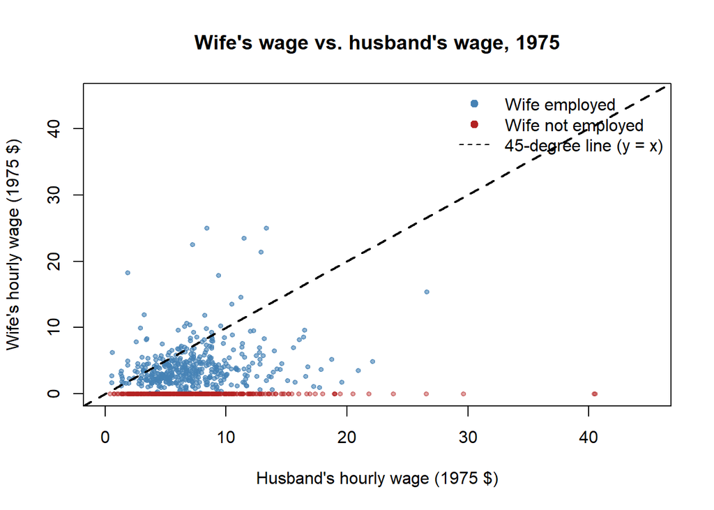

```r
plot(psid$hwage, psid$wage,
     pch  = 19,
     cex  = 0.6,
     col  = ifelse(psid$employed == 1,
                   rgb(0.27, 0.51, 0.71, 0.6),
                   rgb(0.70, 0.13, 0.13, 0.4)),
     main = "Wife's wage vs. husband's wage, 1975",
     xlab = "Husband's hourly wage (1975 $)",
     ylab = "Wife's hourly wage (1975 $)",
     xlim = c(0, 45),
     ylim = c(0, 45))
abline(a = 0, b = 1, lty = 2, lwd = 2)
legend("topright",
       legend = c("Wife employed", "Wife not employed", "45-degree line (y = x)"),
       col    = c("steelblue", "firebrick", "black"),
       pch    = c(19, 19, NA),
       lty    = c(NA, NA, 2),
       bty    = "n")
```

*** Most husbands have an hourly wage of less than $10, regardless of their wives’ employment status.

## Question 3

For this question, you will estimate two regressions. First, you will estimate a model to explain a woman’s wages using characteristics pertaining to her and/or her husband. Second, estimate the same model using only the subset of women with non-zero wages. At the end, use functions from the `modelsummary` package to present the results.

1. Estimate a model where a woman’s wages is a function of factors pertaining to her and/or her husband. You may use any variable, or combination of variables, except for the variable that indicates whether a woman is employed. Include *every* variable you believe belongs in the model. For each variable you choose to include, provide (i) the sign you expect its coefficient to have, and (ii) a one-sentence story for *why* the variable affects wages. (**2 Points**)

```r
f_wage <- wage ~ education + age + youngkids + oldkids +
                 heducation + hwage + hhours + unemp + city

m_all <- lm(f_wage, data = psid)
summary(m_all)
```

```
Call:
lm(formula = f_wage, data = psid)

Residuals:
    Min      1Q  Median      3Q     Max
-4.8150 -1.9761 -0.4724  1.3498 23.6197

Coefficients:
              Estimate Std. Error t value Pr(>|t|)
(Intercept)  0.4256515  1.1532741   0.369  0.71217
education    0.5567337  0.0614666   9.058  < 2e-16 ***
age         -0.0433176  0.0167490  -2.586  0.00989 **
youngkids   -1.1941214  0.2344174  -5.094 4.45e-07 ***
oldkids     -0.0964391  0.0917156  -1.052  0.29337
heducation  -0.0930780  0.0495301  -1.879  0.06061 .
hwage       -0.0265883  0.0306511  -0.867  0.38598
hhours      -0.0004981  0.0001976  -2.521  0.01191 *
unemp       -0.0320960  0.0364890  -0.880  0.37936
city         0.2070990  0.2482075   0.834  0.40434
---
Signif. codes:  0 '***' 0.001 '**' 0.01 '*' 0.05 '.' 0.1 ' ' 1

Residual standard error: 3.01 on 743 degrees of freedom
Multiple R-squared:  0.1484,    Adjusted R-squared:  0.1381
F-statistic: 14.39 on 9 and 743 DF,  p-value: < 2.2e-16
```

### Discussion

*** Education – Positive. Education has a positive and significant impact on wages. This is generally true.

*** Age – Ambiguous. We can explain it in two ways. If someone works in a blue-collar job, age might have a negative impact on wages. But if someone works in a white-collar job, age might have a positive impact because experience can increase salary.

*** Young kids – Negative. Mothers need to give more attention to young kids, which might have a negative impact on their jobs and wages.

*** Old kids – Positive or slightly negative. Mothers still need to give attention to their kids, but the negative impact might be very small because older kids usually need less attention.

*** Husband’s education (heducation) – Positive. An educated husband may positively encourage and support his wife’s career.

*** Husband’s wage (hwage) – Positive. A higher husband’s wage might create more competition between the husband and wife. :-P

*** Unemployment (unemp) – Negative. Usually, high unemployment is associated with lower wages.

*** City – Positive. Cities create more jobs and provide more employment opportunities.

2. Re-estimate the model using only the subset of employed women. (**1 Point**)

```r
m_emp <- lm(f_wage, data = subset(psid, wage > 0))
summary(m_emp)
```

```
Call:
lm(formula = f_wage, data = subset(psid, wage > 0))

Residuals:
    Min      1Q  Median      3Q     Max
-6.4828 -1.6442 -0.4975  0.9531 21.0300

Coefficients:
              Estimate Std. Error t value Pr(>|t|)
(Intercept) -1.773e+00  1.539e+00  -1.152   0.2501
education    5.220e-01  8.339e-02   6.260 9.58e-10 ***
age          6.982e-03  2.279e-02   0.306   0.7594
youngkids    7.011e-02  4.122e-01   0.170   0.8650
oldkids     -9.393e-02  1.265e-01  -0.742   0.4582
heducation  -1.197e-01  6.642e-02  -1.803   0.0722 .
hwage        1.292e-01  5.181e-02   2.493   0.0131 *
hhours      -2.969e-05  2.881e-04  -0.103   0.9180
unemp       -4.227e-02  5.145e-02  -0.822   0.4117
city         2.668e-01  3.425e-01   0.779   0.4365
---
Signif. codes:  0 '***' 0.001 '**' 0.01 '*' 0.05 '.' 0.1 ' ' 1

Residual standard error: 3.099 on 418 degrees of freedom
Multiple R-squared:  0.1423,    Adjusted R-squared:  0.1238
F-statistic: 7.706 on 9 and 418 DF,  p-value: 1.651e-10
```

3. Display the coefficients from both estimations in a single table. (**1 Point**)

```r
modelsummary(
  list("(1) All women" = m_all, "(2) Employed only" = m_emp),
  stars     = c("*" = 0.1, "**" = 0.05, "***" = 0.01),
  fmt       = 4,
  gof_map   = c("nobs", "r.squared", "adj.r.squared"),
  title     = "Table 3: OLS estimates of the wife's hourly wage (1975 $)",
  notes     = "Column (1) treats non-participants as earning $0. Column (2) drops them."
)
```

Table 3: OLS estimates of the wife's hourly wage (1975 $)

|  | (1) All women | (2) Employed only |
| --- | --- | --- |
| (Intercept) | 0.4257 | -1.7729 |
|  | (1.1533) | (1.5392) |
| education | 0.5567*** | 0.5220*** |
|  | (0.0615) | (0.0834) |
| age | -0.0433*** | 0.0070 |
|  | (0.0167) | (0.0228) |
| youngkids | -1.1941*** | 0.0701 |
|  | (0.2344) | (0.4122) |
| oldkids | -0.0964 | -0.0939 |
|  | (0.0917) | (0.1265) |
| heducation | -0.0931* | -0.1197* |
|  | (0.0495) | (0.0664) |
| hwage | -0.0266 | 0.1292** |
|  | (0.0307) | (0.0518) |
| hhours | -0.0005** | -0.0000 |
|  | (0.0002) | (0.0003) |
| unemp | -0.0321 | -0.0423 |
|  | (0.0365) | (0.0514) |
| city | 0.2071 | 0.2668 |
|  | (0.2482) | (0.3425) |
| Num.Obs. | 753 | 428 |
| R2 | 0.148 | 0.142 |
| R2 Adj. | 0.138 | 0.124 |

* p < 0.1, ** p < 0.05, *** p < 0.01  
Column (1) treats non-participants as earning $0. Column (2) drops them.

4. Interpret the coefficients in the regressions. (**2 Points**) *** education- For all women; One more year of the wife’s schooling is associated with a $0.56 higher hourly wage and on the other hand for employed women salary increase rate is $0.52

*** age - Each additional year of age is reduce $0.04 per hour wage. Its opposite of our expectation. For employed women this result is not significant.

*** youngkids` - Each additional child under six is associated with $1.19 less per hour, for employed women its insignificant.

5. Do any of the coefficients change between regressions? Why or why not? Which regression do you prefer, and why? (**1 Point**)

*** yea, 3 varibales coefficient have changed. Those are age,youngkids,hwage. These varibales have direct impact for women those employed. I prefer employed only regression. Its give precise and actual information.

## Question 4

The exercise in this question will be very similar to the last one, except the dependent variable will be binary.

1. Estimate a model that explains female employment status. Again, you may choose which variables you would like to use in the model, but you may not use the woman’s wages as an explanatory variable. For each variable you choose to include, provide (i) the sign you expect its coefficient to have, and (ii) a one-sentence story for *why* the variable affects employment. (**1 Point**)

| Variable | Expected sign | Why it belongs |
| --- | --- | --- |
| `education` | **+** | A better-educated woman commands a higher market wage, which is more likely to clear her reservation wage. |
| `age` | **−** | Older women in this cohort face weaker attachment, more health limitations, and approaching retirement. |
| `youngkids` | **−** | A preschooler requires care that was expensive or unavailable in 1975, so it raises the reservation wage sharply. |
| `oldkids` | **−** (small) | School-age children still need supervision, but school hours absorb most of the constraint. |
| `heducation` | **−** | Husband’s schooling proxies for permanent household income, and a richer household buys more leisure. |
| `hwage` | **−** | A pure income effect: higher household income raises the wife’s reservation wage. |
| `hhours` | **−** | A husband already supplying long hours signals a household specialized in his market work and her home production. |
| `unemp` | **−** | Fewer job openings mean fewer offers and more discouraged workers. |
| `city` | **+** | Thicker urban labor markets offer more part-time and clerical jobs suited to a second earner. |

```r
f_emp <- employed ~ education + age + youngkids + oldkids +
                    heducation + hwage + hhours + unemp + city

m_lpm   <- lm(f_emp, data = psid)
m_logit <- glm(f_emp, data = psid, family = binomial(link = "logit"))

summary(m_lpm)
```

```
Call:
lm(formula = f_emp, data = psid)

Residuals:
    Min      1Q  Median      3Q     Max
-0.9172 -0.4626  0.1816  0.3788  0.8838

Coefficients:
              Estimate Std. Error t value Pr(>|t|)
(Intercept)  9.636e-01  1.758e-01   5.481 5.81e-08 ***
education    5.923e-02  9.371e-03   6.321 4.49e-10 ***
age         -1.286e-02  2.554e-03  -5.038 5.91e-07 ***
youngkids   -3.014e-01  3.574e-02  -8.433  < 2e-16 ***
oldkids     -1.164e-02  1.398e-02  -0.832 0.405432
heducation  -6.807e-03  7.551e-03  -0.901 0.367674
hwage       -1.661e-02  4.673e-03  -3.554 0.000403 ***
hhours      -1.056e-04  3.012e-05  -3.506 0.000482 ***
unemp       -4.808e-03  5.563e-03  -0.864 0.387670
city         2.838e-03  3.784e-02   0.075 0.940227
---
Signif. codes:  0 '***' 0.001 '**' 0.01 '*' 0.05 '.' 0.1 ' ' 1

Residual standard error: 0.4588 on 743 degrees of freedom
Multiple R-squared:  0.1532,    Adjusted R-squared:  0.1429
F-statistic: 14.93 on 9 and 743 DF,  p-value: < 2.2e-16
```

2. Display the coefficients in a table. (**1 Point**)

```r
modelsummary(
  list("(1) LPM" = m_lpm, "(2) Logit" = m_logit),
  stars   = c("*" = 0.1, "**" = 0.05, "***" = 0.01),
  fmt     = 4,
  gof_map = c("nobs", "r.squared", "adj.r.squared", "aic"),
  title   = "Table 4: Models of the wife's 1975 employment status",
  notes   = "Column (2) reports raw logit coefficients, not marginal effects."
)
```

Table 4: Models of the wife's 1975 employment status

|  | (1) LPM | (2) Logit |
| --- | --- | --- |
| (Intercept) | 0.9636*** | 2.2739*** |
|  | (0.1758) | (0.8674) |
| education | 0.0592*** | 0.2864*** |
|  | (0.0094) | (0.0478) |
| age | -0.0129*** | -0.0633*** |
|  | (0.0026) | (0.0129) |
| youngkids | -0.3014*** | -1.4964*** |
|  | (0.0357) | (0.1968) |
| oldkids | -0.0116 | -0.0651 |
|  | (0.0140) | (0.0683) |
| heducation | -0.0068 | -0.0303 |
|  | (0.0076) | (0.0363) |
| hwage | -0.0166*** | -0.0844*** |
|  | (0.0047) | (0.0241) |
| hhours | -0.0001*** | -0.0005*** |
|  | (0.0000) | (0.0001) |
| unemp | -0.0048 | -0.0228 |
|  | (0.0056) | (0.0267) |
| city | 0.0028 | 0.0393 |
|  | (0.0378) | (0.1820) |
| Num.Obs. | 753 | 753 |
| R2 | 0.153 |  |
| R2 Adj. | 0.143 |  |
| AIC | 975.6 | 923.5 |

* p < 0.1, ** p < 0.05, *** p < 0.01  
Column (2) reports raw logit coefficients, not marginal effects.

3. Interpret each coefficient in the regression. (**2 Points**)

*** education — Each additional year of the wife’s schooling raises her probability of working by 5.9 percentage points, so a four-year college degree over high school implies roughly 24 points.

*** age — Each additional year of age lowers the probability of working by 1.3 points, reflecting weaker labor force attachment among older women in this cohort.

*** youngkids — Each child under six lowers the probability of employment by 30 percentage points, cutting the 56.8% base participation rate roughly in half.

*** oldkids — Each school-age child lowers the probability by only 1.2 points and is statistically indistinguishable from zero, so it is the age of the child rather than the number that constrains labor supply.

*** heducation — insignificant

*** hwage — Each additional dollar per hour the husband earns lowers the wife’s probability of working by 1.7 points, a clear income effect on her reservation wage.

*** hhours — One hundred additional husband hours per year lower her probability of working by 1.1 points, consistent with household specialization.

## Question 5

Discuss yours findings from the regressions above. What does this tell you about women from the mid 1970s? Did anything surprise you? How do you think these regressions would differ if the sample contained data collected from women of today? (**1 Point**)

## Footnotes

[^1]: For example, what is the average age gap within couples? What is the average wage gap? What percent of sampled females were employed in 1975? What is the average number of children of the women sampled?